# Homework 5

Meredith Tucker: mltucker2001

3/5/20

## Liquor Sales in Iowa

This dataset https://data.iowa.gov/Sales-Distribution/2019-Iowa-Liquor-Sales/38x4-vs5h contains the spirits purchase information of Iowa Class “E” liquor licensees by product and date of purchase for 2019. The dataset can be used to analyze total spirits sales in Iowa of individual products at the store level.

**Submission instructions**: Create a folder named `ds202_hw5`, and name the RMarkDown file including your solutions `hw5.Rmd` under this folder. For the submission, create a GitHub repository named `ds202_hw5` under your GitHub account, and push both `hw5.Rmd` and the knitted `hw5.html` before the deadline. I will assume you use the same GitHub username as for your HW4 submission. The latest version of your homework appearing on GitHub before the deadline is graded. *It is crucial to follow the exact folder structure and file names*, so that your homework can be reproduced and graded by an automated script. This homework is **due on April 10** by 11:59 pm.

1. The complete dataset is too large. Download and import the alcohol sales data for Ames only:
1. Go to https://data.iowa.gov/Sales-Distribution/2019-Iowa-Liquor-Sales/38x4-vs5h
2. Click Filter – Filter – Go advanced now
3. Add a New Filter Condition: City is Ames.
4. Export – CSV – Download
5. Use `readr::read_csv` to import.

```r
ILSales <- readr::read_csv('2019_Iowa_Liquor_Sales.csv')
```

2. Data cleaning:
1. extract geographic latitude and longitude from the variable `Store Location`

```r
ILSales <- na.omit(ILSales)
ILSales$'Store Location' <- gsub(ILSales$'Store Location', pattern = 'POINT ', replacement = '')
ILSales <- ILSales %>%
  separate('Store Location', c('Latitude', 'Longitude'),
           sep = " ")
ILSales$Latitude <- gsub(ILSales$Latitude, pattern = "[(]", replacement = "")
ILSales$Longitude <- gsub(ILSales$Longitude, pattern = "[)]", replacement = "")
head(ILSales)
```

```
## # A tibble: 6 x 25
##   `Invoice/Item N~ Date  `Store Number` `Store Name` Address City  `Zip Code`
##   <chr>            <chr>          <dbl> <chr>        <chr>   <chr>      <dbl>
## 1 INV-16835000019  01/0~           4509 AJ'S LIQUOR~ 2515 C~ Ames       50010
## 2 INV-16886300007  01/1~           5187 Kwik Stop L~ 125 6t~ Ames       50010
## 3 INV-17377700173  02/0~           4129 Cyclone Liq~ 626 Li~ Ames       50010
## 4 INV-17376600028  02/0~           3973 MMDG SPIRIT~ 126A W~ Ames       50014
## 5 INV-17377300189  02/0~           2501 Hy-Vee  #2 ~ 640 Li~ Ames       50010
## 6 INV-17524000103  02/1~           4129 Cyclone Liq~ 626 Li~ Ames       50010
## # ... with 18 more variables: Latitude <chr>, Longitude <chr>, `County
## #   Number` <dbl>, County <chr>, Category <dbl>, `Category Name` <chr>, `Vendor
## #   Number` <chr>, `Vendor Name` <chr>, `Item Number` <dbl>, `Item
## #   Description` <chr>, Pack <dbl>, `Bottle Volume (ml)` <dbl>, `State Bottle
## #   Cost` <dbl>, `State Bottle Retail` <dbl>, `Bottles Sold` <dbl>, `Sale
## #   (Dollars)` <dbl>, `Volume Sold (Liters)` <dbl>, `Volume Sold
## #   (Gallons)` <dbl>
```

2. make sure the variables are in the correct type, by converting incorrect variable types.

```r
str(ILSales)
```

```
## Classes 'tbl_df', 'tbl' and 'data.frame':    48175 obs. of  25 variables:
##  $ Invoice/Item Number  : chr  "INV-16835000019" "INV-16886300007" "INV-17377700173" "INV-17376600028" ...
##  $ Date                 : chr  "01/09/2019" "01/11/2019" "02/06/2019" "02/06/2019" ...
##  $ Store Number         : num  4509 5187 4129 3973 2501 ...
##  $ Store Name           : chr  "AJ'S LIQUOR II" "Kwik Stop Liquor & Groceries Ames" "Cyclone Liquors" "MMDG SPIRITS / Ames" ...
##  $ Address              : chr  "2515 Chamberlain" "125 6th ST" "626 Lincoln Way" "126A Welch Ave" ...
##  $ City                 : chr  "Ames" "Ames" "Ames" "Ames" ...
##  $ Zip Code             : num  50010 50010 50010 50014 50010 ...
##  $ Latitude             : chr  "-93.650838" "-93.611773" "-93.618911" "-93.650131" ...
##  $ Longitude            : chr  "42.021461" "42.026938" "42.022854" "42.021789" ...
##  $ County Number        : num  85 85 85 85 85 85 85 85 85 85 ...
##  $ County               : chr  "STORY" "STORY" "STORY" "STORY" ...
##  $ Category             : num  1031200 1032100 1081400 1081300 1081200 ...
##  $ Category Name        : chr  "American Flavored Vodka" "Imported Vodkas" "American Schnapps" "American Cordials & Liqueur" ...
##  $ Vendor Number        : chr  "259" "035" "065" "434" ...
##  $ Vendor Name          : chr  "Heaven Hill Brands" "BACARDI USA INC" "Jim Beam Brands" "LUXCO INC" ...
##  $ Item Number          : num  36606 34359 82787 76487 80447 ...
##  $ Item Description     : chr  "Deep Eddy Orange" "Grey Goose" "Dekuyper Buttershots" "Paramount Amaretto" ...
##  $ Pack                 : num  12 12 12 12 6 24 6 12 6 12 ...
##  $ Bottle Volume (ml)   : num  750 200 1000 1000 750 200 1750 750 1750 750 ...
##  $ State Bottle Cost    : num  9 5 7.87 4.05 10 6.24 13 5.48 7.17 9.01 ...
##  $ State Bottle Retail  : num  13.5 7.5 11.81 6.08 15 ...
##  $ Bottles Sold         : num  2 12 1 7 6 3 6 2 6 12 ...
##  $ Sale (Dollars)       : num  27 90 11.8 42.6 90 ...
##  $ Volume Sold (Liters) : num  1.5 2.4 1 7 4.5 0.6 10.5 1.5 10.5 9 ...
##  $ Volume Sold (Gallons): num  0.39 0.63 0.26 1.84 1.18 0.15 2.77 0.39 2.77 2.37 ...
```

```r
ILSales$Latitude <- as.numeric(ILSales$Latitude)
ILSales$Longitude <- as.numeric(ILSales$Longitude)
str(ILSales)
```

```
## Classes 'tbl_df', 'tbl' and 'data.frame':    48175 obs. of  25 variables:
##  $ Invoice/Item Number  : chr  "INV-16835000019" "INV-16886300007" "INV-17377700173" "INV-17376600028" ...
##  $ Date                 : chr  "01/09/2019" "01/11/2019" "02/06/2019" "02/06/2019" ...
##  $ Store Number         : num  4509 5187 4129 3973 2501 ...
##  $ Store Name           : chr  "AJ'S LIQUOR II" "Kwik Stop Liquor & Groceries Ames" "Cyclone Liquors" "MMDG SPIRITS / Ames" ...
##  $ Address              : chr  "2515 Chamberlain" "125 6th ST" "626 Lincoln Way" "126A Welch Ave" ...
##  $ City                 : chr  "Ames" "Ames" "Ames" "Ames" ...
##  $ Zip Code             : num  50010 50010 50010 50014 50010 ...
##  $ Latitude             : num  -93.7 -93.6 -93.6 -93.7 -93.6 ...
##  $ Longitude            : num  42 42 42 42 42 ...
##  $ County Number        : num  85 85 85 85 85 85 85 85 85 85 ...
##  $ County               : chr  "STORY" "STORY" "STORY" "STORY" ...
##  $ Category             : num  1031200 1032100 1081400 1081300 1081200 ...
##  $ Category Name        : chr  "American Flavored Vodka" "Imported Vodkas" "American Schnapps" "American Cordials & Liqueur" ...
##  $ Vendor Number        : chr  "259" "035" "065" "434" ...
##  $ Vendor Name          : chr  "Heaven Hill Brands" "BACARDI USA INC" "Jim Beam Brands" "LUXCO INC" ...
##  $ Item Number          : num  36606 34359 82787 76487 80447 ...
##  $ Item Description     : chr  "Deep Eddy Orange" "Grey Goose" "Dekuyper Buttershots" "Paramount Amaretto" ...
##  $ Pack                 : num  12 12 12 12 6 24 6 12 6 12 ...
##  $ Bottle Volume (ml)   : num  750 200 1000 1000 750 200 1750 750 1750 750 ...
##  $ State Bottle Cost    : num  9 5 7.87 4.05 10 6.24 13 5.48 7.17 9.01 ...
##  $ State Bottle Retail  : num  13.5 7.5 11.81 6.08 15 ...
##  $ Bottles Sold         : num  2 12 1 7 6 3 6 2 6 12 ...
##  $ Sale (Dollars)       : num  27 90 11.8 42.6 90 ...
##  $ Volume Sold (Liters) : num  1.5 2.4 1 7 4.5 0.6 10.5 1.5 10.5 9 ...
##  $ Volume Sold (Gallons): num  0.39 0.63 0.26 1.84 1.18 0.15 2.77 0.39 2.77 2.37 ...
```

3. extract year, month and day from the variable `Date` as separate columns.

```r
ILSales$Date <- mdy(ILSales$Date)
ILSales <- ILSales %>%
  mutate(Year = year(Date),
         Month = month(Date),
         Day = day(Date))
head(ILSales)
```

```
## # A tibble: 6 x 28
##   `Invoice/Item N~ Date       `Store Number` `Store Name` Address City
##   <chr>            <date>              <dbl> <chr>        <chr>   <chr>
## 1 INV-16835000019  2019-01-09           4509 AJ'S LIQUOR~ 2515 C~ Ames
## 2 INV-16886300007  2019-01-11           5187 Kwik Stop L~ 125 6t~ Ames
## 3 INV-17377700173  2019-02-06           4129 Cyclone Liq~ 626 Li~ Ames
## 4 INV-17376600028  2019-02-06           3973 MMDG SPIRIT~ 126A W~ Ames
## 5 INV-17377300189  2019-02-06           2501 Hy-Vee  #2 ~ 640 Li~ Ames
## 6 INV-17524000103  2019-02-13           4129 Cyclone Liq~ 626 Li~ Ames
## # ... with 22 more variables: `Zip Code` <dbl>, Latitude <dbl>,
## #   Longitude <dbl>, `County Number` <dbl>, County <chr>, Category <dbl>,
## #   `Category Name` <chr>, `Vendor Number` <chr>, `Vendor Name` <chr>, `Item
## #   Number` <dbl>, `Item Description` <chr>, Pack <dbl>, `Bottle Volume
## #   (ml)` <dbl>, `State Bottle Cost` <dbl>, `State Bottle Retail` <dbl>,
## #   `Bottles Sold` <dbl>, `Sale (Dollars)` <dbl>, `Volume Sold (Liters)` <dbl>,
## #   `Volume Sold (Gallons)` <dbl>, Year <dbl>, Month <dbl>, Day <int>
```

3. First overview:
1. Plot a scatterplot of lat and long of store locations.

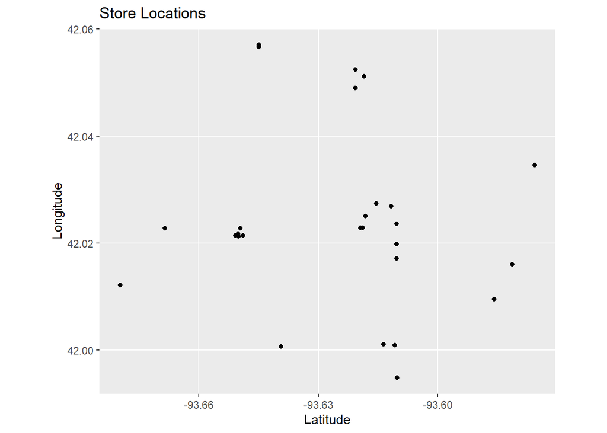

```r
ggplot(ILSales, aes(x=Latitude, y=Longitude)) + geom_point() + ggtitle("Store Locations") + xlab('Latitude') + ylab('Longitude') + coord_map()
```

2. Provide a visual breakdown of the liquor category (by `Category Name`). Include volume sold in the breakdown.

```r
Vol <- ILSales %>%
  group_by(`Category Name`) %>%
  summarize(Liters_Sold = sum(`Volume Sold (Liters)`),
            Gallons_Sold = sum(`Volume Sold (Gallons)`),
            Count_Sales= n())
Vol
```

```
## # A tibble: 51 x 4
##    `Category Name`                      Liters_Sold Gallons_Sold Count_Sales
##    <chr>                                      <dbl>        <dbl>       <int>
##  1 100% Agave Tequila                         7711.      2027.          1529
##  2 Aged Dark Rum                               895.       235.           240
##  3 American Brandies                          5918.      1557.          1057
##  4 American Cordials & Liqueur                3679.       967.           969
##  5 American Distilled Spirit Specialty         247.        64.6           80
##  6 American Distilled Spirits Specialty          9          2.36           2
##  7 American Dry Gins                          9760.      2572.          1155
##  8 American Flavored Vodka                   23557.      6204.          3139
##  9 American Schnapps                          9442.      2488.          1342
## 10 American Sloe Gins                           30          7.92           3
## # ... with 41 more rows
```

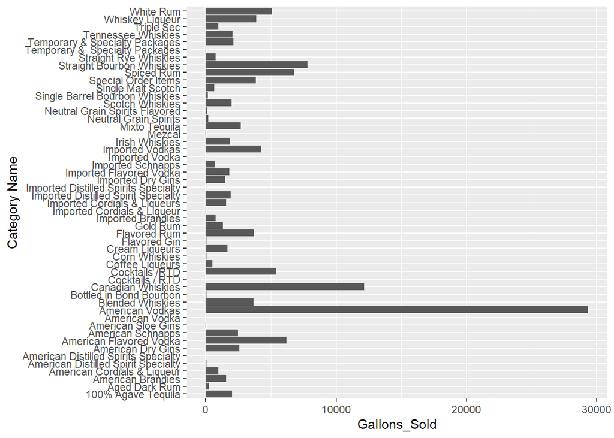

```r
ggplot(data=Vol, aes(x=`Category Name`, y= Gallons_Sold)) + geom_bar(stat='identity') + coord_flip()
```

4. Find the daily sales liquor sales in Ames in 2019. Summarize the number of sales, volume of liquor sold, and amount of money spent.

```r
daily <- ILSales %>%
  group_by(Date) %>%
  group_by(Date) %>%
  summarize(Liters_Sold = sum(`Volume Sold (Liters)`),
            Gallons_Sold = sum(`Volume Sold (Gallons)`),
            Money_spent = sum(`Sale (Dollars)`),
            Num_Sales = n())
daily
```

```
## # A tibble: 146 x 5
##    Date       Liters_Sold Gallons_Sold Money_spent Num_Sales
##    <date>           <dbl>        <dbl>       <dbl>     <int>
##  1 2019-01-03       4944.       1302.       83304.       767
##  2 2019-01-04       1256.        331.       16766.       143
##  3 2019-01-09       5616.       1480.       82540.       701
##  4 2019-01-10        135          35.6       1457.         2
##  5 2019-01-11       1038.        273.       14427.       153
##  6 2019-01-16       6748.       1779        95180.       632
##  7 2019-01-24       7167.       1888.      105730.       900
##  8 2019-01-25       2329.        614.       31893.       253
##  9 2019-01-30       7132.       1880.      103468.       795
## 10 2019-01-31        154.         40.7       2223         18
## # ... with 136 more rows
```

5. Plot volume sold by day (use a scatterplot of volume by day and facet by month). Discover trends with the help of `geom_smooth`. Describe any patterns.

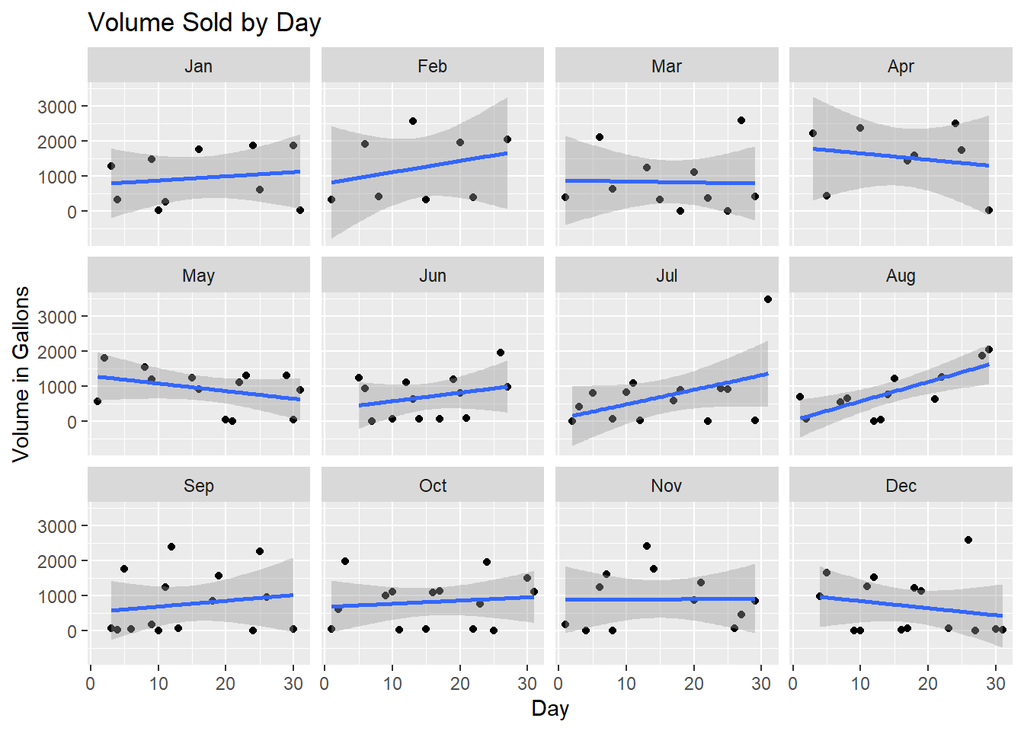

```r
daily %>% ggplot(aes(x=day(Date), y=Gallons_Sold)) + geom_point() + geom_smooth(method='lm') + facet_wrap(. ~month(Date, label=TRUE)) + xlab('Day') + ylab('Volume in Gallons') + ggtitle('Volume Sold by Day')
```

There appears to be a pattern of increased sales during the school year. The summer months have smaller number of sales compared to the rest of the year and then rise at the end of July. Also the appears to be a decrease in sales as the spring semester end. There are also peaks in each month, this could be due to weekends.

6. Find the dates for ISU football home games in Fall 2019. Can you see a pattern?

The dates of the Fall 2019 ISU home football games are Aug 31, Sept 14, Sept 21, Oct 5, Oct 26, Nov 16, and Nov 23. There is a tendency in the graphs to show an increase of liquor sales near the dates of the home football games. Usually the increased sales occur a day or so before the game. Also it appears that in months such as September and November that the first home football game of the month have a higher sale level compared to the second game of the month.

Note: your submission is supposed to be fully reproducible, i.e. the TA and I will ‘knit’ your submission in RStudio.